# Cardio Vascular Disease Project

Team 1

2022-08-06

```r
library(ezids)
library(ggplot2)
library(dplyr)
knitr::opts_chunk$set(warning = F, results = "hide", message = F)
options(scientific=T, digits = 3)
```

This is how we import the dataset.

```r
CVD <- data.frame(read.csv("cardio_train.csv", sep=";"))
View(CVD)
```

## Chapter 1: Introduction to Cardiovascular Diseases (CVDs)

# 1.1 Basic Information About Cardiovascular Diseases (CVDs)

Cardiovascular Disease is a general name for numerous types of diseases including heart attack, stroke, and heart failure. In 2019 an estimated 17.9 million people died from Cardiovascular Diseases and 85% were due to heart attack and stroke.

# 1.2 Reasons of Choosing Cardiovascular Disease.

As living standards are improving over the past few decades, having a healthy lifestyle and avoiding serious illnesses have become people’s priorities and Cardiovascular diseases are the leading cause of death globally our group is interested in finding out some facts about Cardiovascular Disease such as what exactly Cardiovascular Diseases are. What are some factors that are correlate to Cardiovascular Diseases, among those factors what have the strongest correlation to Cardiovascular Diseases? And would a healthy lifestyle help to prevent people from having cardiovascular disease? Therefore, our group choose this dataset about Cardiovascular Diseases

## Chapter 2: Summary of the Dataset

# 2.1:About the Dataset

The Cardiovascular Diseases dataset is extracted from Kaggle. It contains information from 70,000 records of patients that provided their age, height, weight, physical condition, and habits. Studying such data can help the public and health organizations identify potential factors that could lead to a higher chance of getting Cardiovascular Diseases, and develop appropriate strategies to reduce the number of patients. The dataset is cardio_train.csv. Before doing any analysis on this dataset, we did some research about what every single variable in the dataset represents, why they are included in this dataset, and what variables we will use in our model. With all those information government agents and the public will know how to adjust their habits or lifestyle to prevent getting Cardiovascular Diseases. Therefore, it is crucial to figure out current problems, and then publish the information.

# 2.2: Variables

This is how we get the dataframe.

```r
str(CVD)
```

The variables are the following:

1.`id`: Respondents’id | id | int

2.`Age`: Respondents’ age | age | int (days)

3.`Height`: Respondents’ height | height | int (cm)

4.`Weight`: Respondents’ weight | weight | num (kg)

5.`Gender`: Respondents’gender | gender | int (1:Feale|2:Male)

6.`Systolic blood pressure`: Respondents’ systolic blood pressure | ap_hi | int

7.`Diastolic blood pressure`: Respondents’ diastolic blood pressure | ap_lo | int

8.`Cholesterol`: Respondents’ cholesterol level | cholesterol | int (1: normal, 2: above normal, 3: well above normal)

9.`Glucose`: Respondents’ glucose level | gluc | int (1: normal, 2: above normal, 3: well above normal)

10.`Smoking`: Whether respondent smokes or not | smoke | int (0:Do not smoke, 1:Smoke)

11.`Alcohol intake`: Whether respondent drink or not | alco | int (0:Do not drink, 1: Drink)

12.`Physical activity`: Respondents’ do not physical activity regularly | active | int (0:Workout regularly, 1: No workout regularly)

13.`Presence or absence of cardiovascular disease`: Respondent present cardiovascular disease | cardio | int (0:No CVD currently present, 1:CVD currently present)

## Chapter 3: Descriptive Statistics

# 3.1 Categorical Variables EDA

# 3.1.1 Are there any common in CVD patients?

We start with smoke history and whether CVD are currently presented or not.

This is how we create a table about the presence of CVD for those who smoke.(Smoke)

```r
library(dplyr)
smoke_con<-aggregate(CVD$cardio, by=list(CVD$smoke,CVD$cardio), FUN=length)
smoke_con<-rename(smoke_con,Smoke = Group.1,CVD_presence = Group.2,CVD = x)
smoke_con$Smoke[smoke_con$Smoke=="0"] <- 'Not smoke'
smoke_con$Smoke[smoke_con$Smoke=="1"] <- 'Smoke'
smoke_con$CVD_presence[smoke_con$CVD_presence=="0"] <- 'Not Present'
smoke_con$CVD_presence[smoke_con$CVD_presence=="1"] <- 'Present'
xkabledply(smoke_con)
```

Model: Smoke ~ CVD_presence + CVD

| Smoke | CVD_presence | CVD |
| --- | --- | --- |
| Not smoke | Not Present | 31781 |
| Smoke | Not Present | 3240 |
| Not smoke | Present | 32050 |
| Smoke | Present | 2929 |

This is how we create a table about CVD for those who drink alcohol (alcohol intake).

```r
alco_con<-aggregate(CVD$cardio,by=list(CVD$alco,CVD$cardio), FUN=length)
alco_con<-rename(alco_con,alco = Group.1,CVD_presence = Group.2,CVD = x)
alco_con$alco[alco_con$alco=="0"] <- 'Not drink'
alco_con$alco[alco_con$alco=="1"] <- 'Drink'
alco_con$CVD_presence[alco_con$CVD_presence=="0"] <- 'Not Present'
alco_con$CVD_presence[alco_con$CVD_presence=="1"] <- 'Present'
xkabledply(alco_con)
```

Model: alco ~ CVD_presence + CVD

| alco | CVD_presence | CVD |
| --- | --- | --- |
| Not drink | Not Present | 33080 |
| Drink | Not Present | 1941 |
| Not drink | Present | 33156 |
| Drink | Present | 1823 |

This is how we create a table about CVD for those who workout (Physical Activity).

```r
active_con<-aggregate(CVD$cardio, by=list(CVD$active,CVD$cardio), FUN=length)
active_con<-rename(active_con,active = Group.1,CVD_presence = Group.2,CVD = x)
active_con$active[active_con$active=="0"] <- 'Physical Activity'
active_con$active[active_con$active=="1"] <- 'Not Physical Activity'
active_con$CVD_presence[active_con$CVD_presence=="0"] <- 'Not Present'
active_con$CVD_presence[active_con$CVD_presence=="1"] <- 'Present'
xkabledply(active_con)
```

Model: active ~ CVD_presence + CVD

| active | CVD_presence | CVD |
| --- | --- | --- |
| Physical Activity | Not Present | 6378 |
| Not Physical Activity | Not Present | 28643 |
| Physical Activity | Present | 7361 |
| Not Physical Activity | Present | 27618 |

# 3.1.2 Plot comparing different factors

This is how we plot the curve of smoke and CVD.

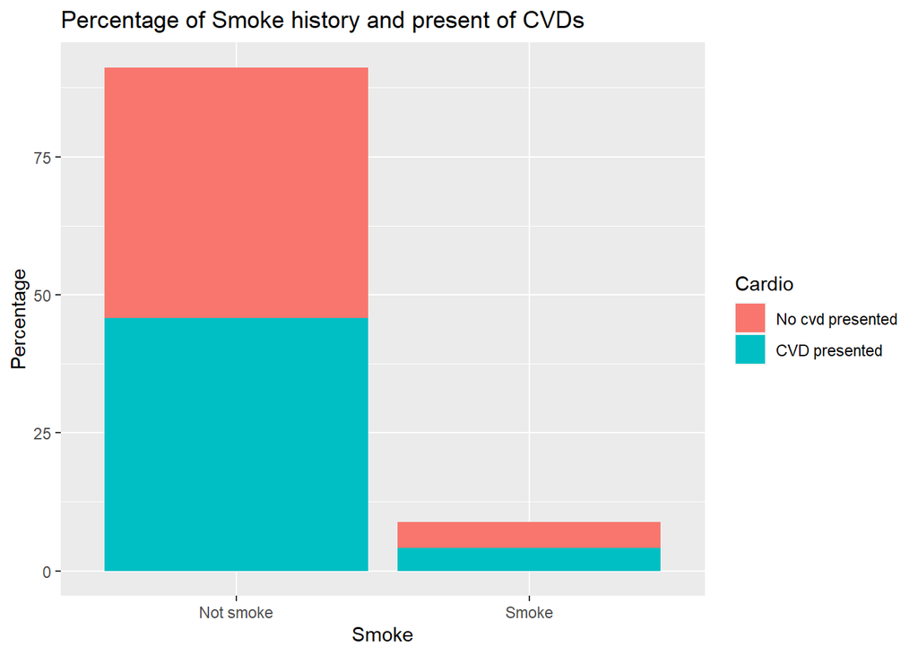

```r
smoke_pic <- data.frame(table(CVD$smoke,CVD$cardio))
names(smoke_pic) <- c("Smoke","Cardio","Count")
ggplot(data=smoke_pic, aes(x=Smoke, y=Count/sum(Count)*100, fill=Cardio)) + geom_bar(stat="identity")+scale_x_discrete(labels=c("0" = "Not smoke", "1" = "Smoke"))+scale_fill_discrete(labels=c("0" = "No cvd presented", "1" = "CVD presented"))+ggtitle("Percentage of Smoke history and present of CVDs") + ylab("Percentage")
```

This is how we plot the curve of alcohol intake and CVD.

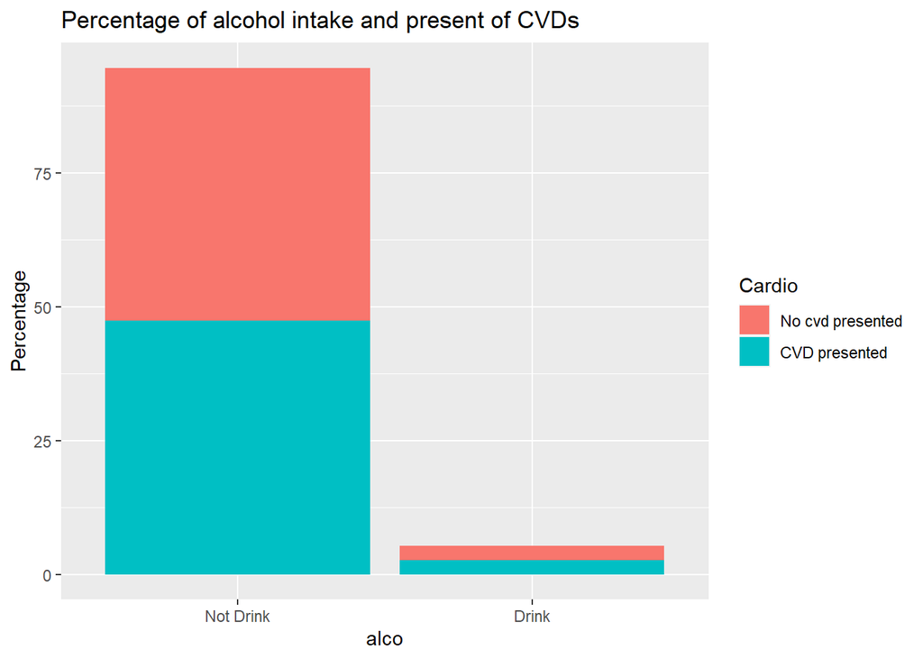

```r
alco_pic <- data.frame(table(CVD$alco,CVD$cardio))
names(alco_pic) <- c("alco","Cardio","Count")
ggplot(data=alco_pic, aes(x=alco, y=Count/sum(Count)*100, fill=Cardio)) + geom_bar(stat="identity")+scale_x_discrete(labels=c("0" = "Not Drink", "1" = "Drink"))+scale_fill_discrete(labels=c("0" = "No cvd presented", "1" = "CVD presented"))+ggtitle("Percentage of alcohol intake and present of CVDs") + ylab("Percentage")
```

This is how we plot the curve of physical activity and CVD.

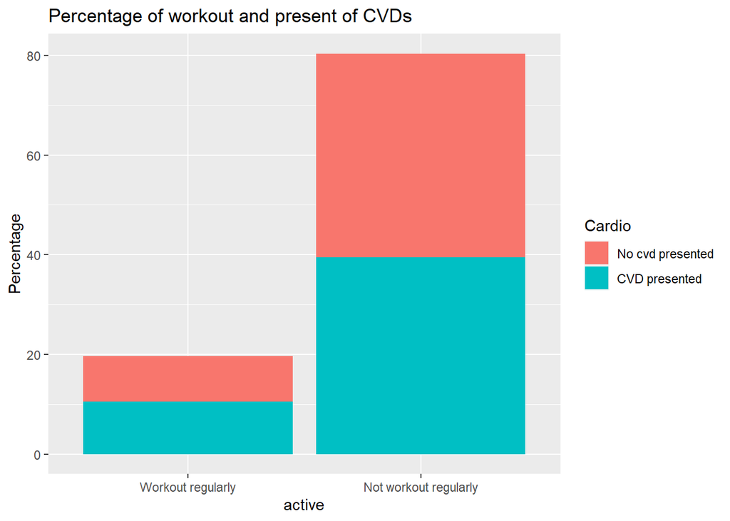

```r
active_pic <- data.frame(table(CVD$active,CVD$cardio))
names(active_pic) <- c("active","Cardio","Count")
ggplot(data=active_pic, aes(x=active, y=Count/sum(Count)*100, fill=Cardio)) + geom_bar(stat="identity")+scale_x_discrete(labels=c("0" = "Workout regularly", "1" = "Not workout regularly"))+scale_fill_discrete(labels=c("0" = "No cvd presented", "1" = "CVD presented"))+ggtitle("Percentage of workout and present of CVDs") + ylab("Percentage")
```

# 3.1.3 Chi-Square Tests

This is how we compute the Chi-square test for Smoke & CVD presence.

```r
smoke_cvd = table(CVD$cardio, CVD$smoke)
```

```r
sctest<- chisq.test(smoke_cvd)
sctest
```

```
##
##  Pearson's Chi-squared test with Yates' continuity correction
##
## data:  smoke_cvd
## X-squared = 17, df = 1, p-value = 4e-05
```

This is how we compute the Chi-square test for Alcohol intake and CVD presence.

```r
al_cvd = table(CVD$cardio, CVD$alco)
```

```r
alctest<- chisq.test(al_cvd)
alctest
```

```
##
##  Pearson's Chi-squared test with Yates' continuity correction
##
## data:  al_cvd
## X-squared = 4, df = 1, p-value = 0.05
```

This is how we compute the Chi-square test for Physical Activity and CVD presence.

```r
act_cvd = table(CVD$cardio, CVD$active)
```

```r
act_test<- chisq.test(act_cvd)
act_test
```

```
##
##  Pearson's Chi-squared test with Yates' continuity correction
##
## data:  act_cvd
## X-squared = 89, df = 1, p-value <2e-16
```

# Chapter 4: Continuous Variables EDA to Cardiovascular Diseases (CVDs)

After a brief overview of the dataset, it tells that there are 3 continuous variables, age, height and weight.

## 4.1 KDE plot of continuous variables

KDE plot represents the data using a continuous probability density curve in one or more dimensions. We can easily observe the distribution of samples with kde plot

This is how we create a new dataframe.

```r
CVD_new$cardio[CVD_new$cardio=="0"] <- 'No CVD Present'
CVD_new$cardio[CVD_new$cardio=="1"] <- 'CVD Present'
CVD_new
```

```r
cols<-c("No CVD Present"="green","CVD Present"="blue")
```

This is how we plot the KDE plot for age.

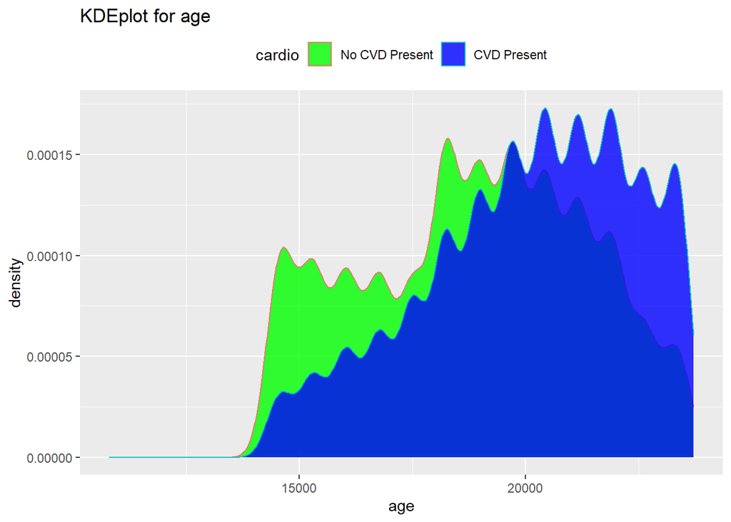

```r
age_kdeplot <- ggplot(data = CVD_new, aes(x = age, color =cardio)) +
            geom_density(aes(fill = cardio), alpha = 0.8) +
             scale_fill_manual(values =cols) +
              labs(title="KDEplot for age") +
               labs(x="age", y="density") +
                theme(legend.position="top")
age_kdeplot
```

This is how we plot the KDE plot for height.

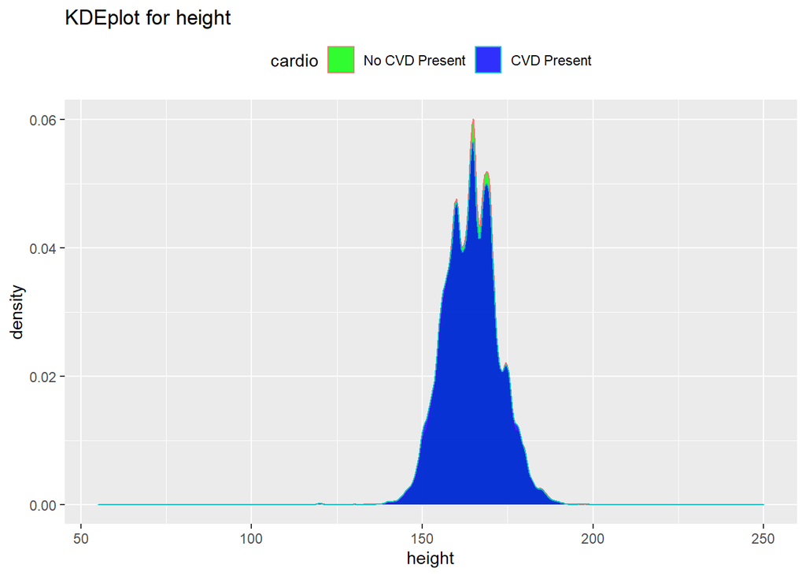

```r
age_kdeplot <- ggplot(data = CVD_new, aes(x = height, color = cardio)) +
            geom_density(aes(fill = cardio), alpha = 0.8) +
             scale_fill_manual(values =cols) +
              labs(title="KDEplot for height") +
               labs(x="height", y="density") +
                theme(legend.position="top")
age_kdeplot
```

This is how we plot the KDE plot for weight.

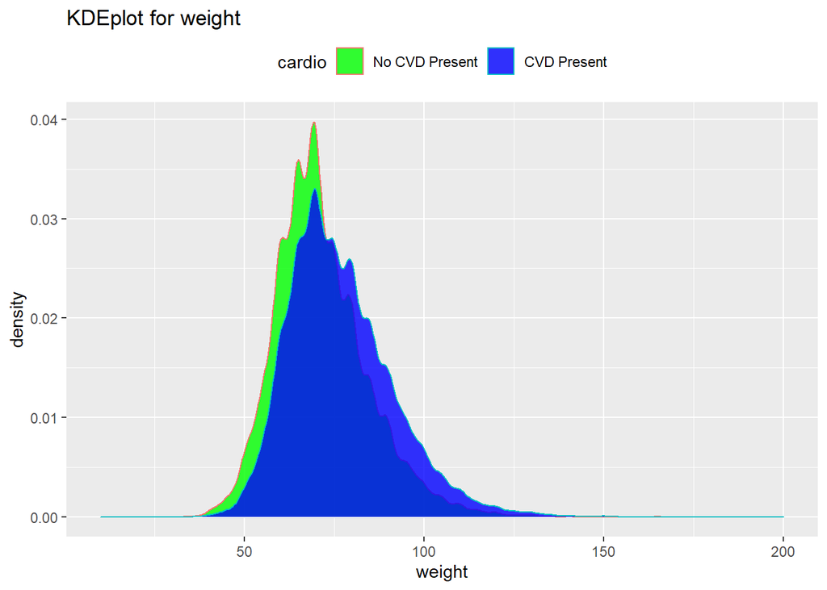

```r
age_kdeplot <- ggplot(data = CVD_new, aes(x = weight, color = cardio)) +
            geom_density(aes(fill = cardio), alpha = 0.8) +
             scale_fill_manual(values= cols) +
              labs(title="KDEplot for weight") +
               labs(x="weight", y="density") +
                theme(legend.position="top")
age_kdeplot
```

## 4.2 Logistic regression

The logit model is often used for classification and predictive analytics. Logistic regression estimates the probability of an event occurring, such as voted or didn’t vote, based on a given dataset of independent variables. Since the outcome is a probability, the dependent variable is bounded between 0 and 1(binary outcome). In this case, “cardio” is the binary outcome; as s result, we choose logistic regression to predict.

This is how we compute the logistic regression with the anova test.

```r
lm1 <- glm(cardio~age, family = binomial(link = "logit"), data = CVD)
lm2 <- glm(cardio~age + weight, family = binomial(link = "logit"), data = CVD)
lm3 <- glm(cardio~age+ height + weight, family = binomial(link = "logit"), data = CVD)
anovat <- anova(lm1,lm2,lm3, test="LRT")
anovat
```

```
## Analysis of Deviance Table
##
## Model 1: cardio ~ age
## Model 2: cardio ~ age + weight
## Model 3: cardio ~ age + height + weight
##   Resid. Df Resid. Dev Df Deviance Pr(>Chi)
## 1     69998      92985
## 2     69997      90810  1     2175   <2e-16 ***
## 3     69996      90656  1      154   <2e-16 ***
## ---
## Signif. codes:  0 '***' 0.001 '**' 0.01 '*' 0.05 '.' 0.1 ' ' 1
```

As it is shown above, model 2 and 3 is better than model 1 . In addition, model 2 and 3 is at 100% significant level.

## 4.3 AUC and ROC Curve

We can use AUC and ROC to measure model 2 and model 3. AUC (Area Under The Curve) - ROC (Receiver Operating Characteristics) curve is a performance measurement for the classification problems at various threshold settings. ROC is a probability curve and AUC represents the degree or measure of separability. It tells how much the model is capable of distinguishing between classes. Higher the AUC, the better the model is at predicting 0 classes as 0 and 1 classes as 1. For summarize, the Higher the AUC, the better the model is.

For model 2:

This is how we plot the ROC curve.

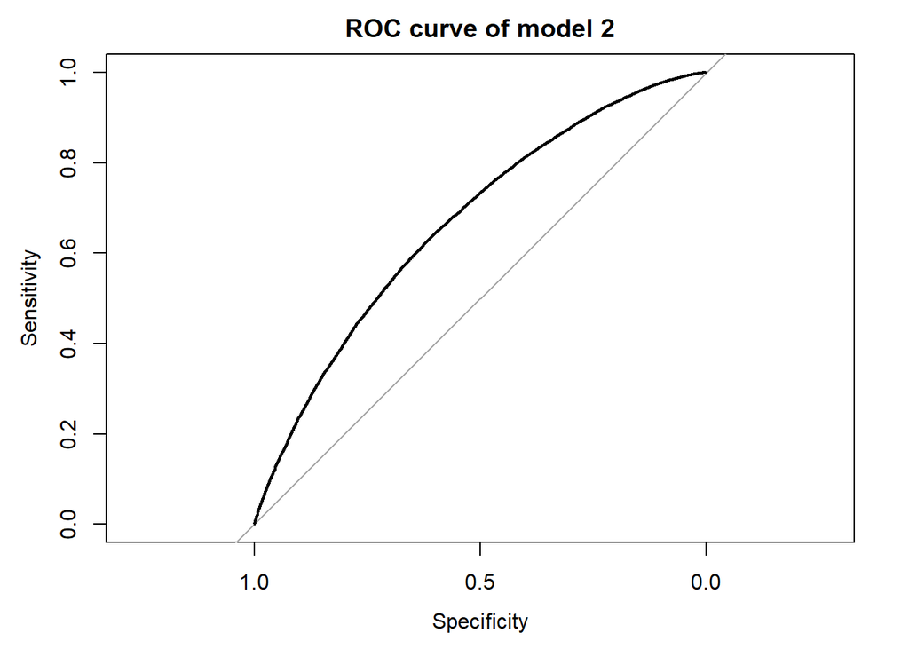

```r
prob <- predict(lm2,CVD, type = c("response"))
CVD$prob <- prob
library(pROC)
g<- roc(cardio~prob, data = CVD)
plot(g, main = "ROC curve of model 2")
```

```r
auc(CVD$cardio, prob)
```

```
## Area under the curve: 0.668
```

The AUC value is 0.668. As 0.668 is much less than 1, this model is not good enough.

This is the summary of model 2.

```r
xkabledply(lm2, title="summary of model 2")
```

summary of model 2

|  | Estimate | Std. Error | z value | Pr(>\|z\|) |
| --- | --- | --- | --- | --- |
| (Intercept) | -5.8347 | 0.0791 | -73.8 | 0 |
| age | 0.0002 | 0.0000 | 60.2 | 0 |
| weight | 0.0262 | 0.0006 | 45.1 | 0 |

For model 3:

This is how we plot the ROC curve.

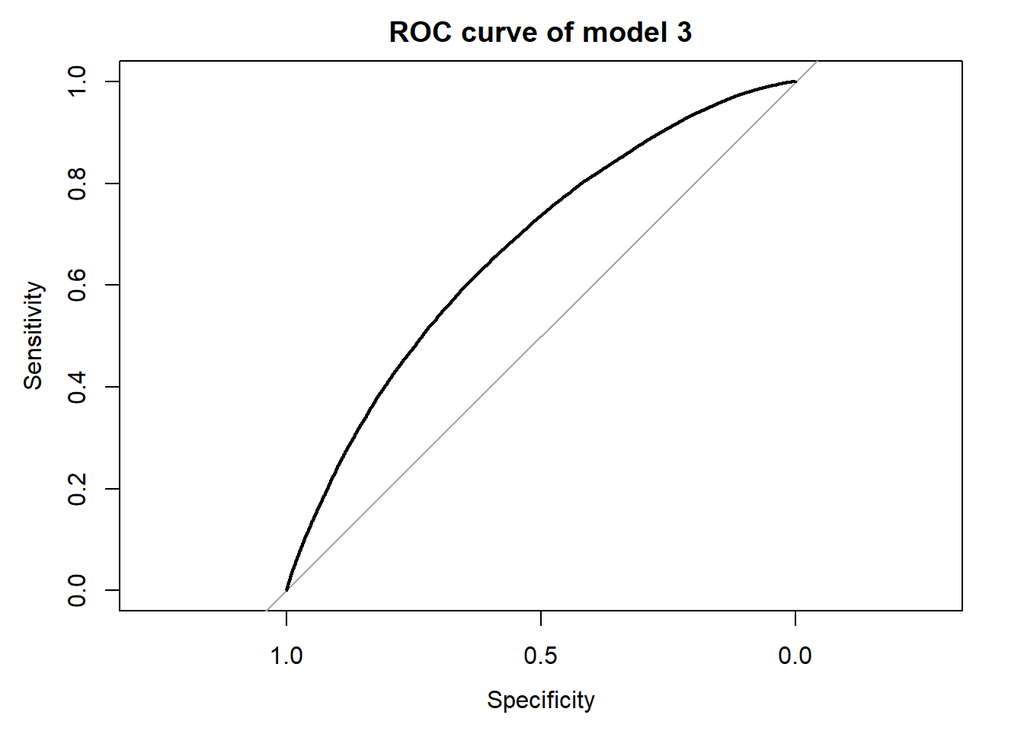

```r
prob1 <- predict(lm3,CVD, type = c("response"))
CVD$prob1 <- prob1
library(pROC)
g<- roc(cardio~prob1, data = CVD)
plot(g, main = "ROC curve of model 3")
```

```r
auc(CVD$cardio, prob1)
```

```
## Area under the curve: 0.671
```

The AUC value is 0.671. As 0.671 is much less than 1 and 0.671 is more than 0.668, this model is not good enough but is better than model 2.

This is the summary of model 3.

```r
xkabledply(lm3, title="summary of model 3")
```

summary of model 3

|  | Estimate | Std. Error | z value | Pr(>\|z\|) |
| --- | --- | --- | --- | --- |
| (Intercept) | -3.8425 | 0.1788 | -21.5 | 0 |
| age | 0.0002 | 0.0000 | 58.8 | 0 |
| height | -0.0127 | 0.0010 | -12.3 | 0 |
| weight | 0.0285 | 0.0006 | 46.4 | 0 |

# 5 Chapter 5: EDA on the joint effect of influencing factors

From the results of above variables, we could find that some of the above variables have a significant effect on CVD. Next, we choose to graph the groups of variables with relatively large correlation coefficients one by one to explore how they affect the Cardio Vascular Disease.

## 5.1 Simple correlations

As most of variables are factors, we check their Spearman correlations.

```r
CVDNum = CVD

str(CVDNum)
```

```
## 'data.frame':    70000 obs. of  15 variables:
##  $ id         : int  0 1 2 3 4 8 9 12 13 14 ...
##  $ age        : int  18393 20228 18857 17623 17474 21914 22113 22584 17668 19834 ...
##  $ gender     : int  2 1 1 2 1 1 1 2 1 1 ...
##  $ height     : int  168 156 165 169 156 151 157 178 158 164 ...
##  $ weight     : num  62 85 64 82 56 67 93 95 71 68 ...
##  $ ap_hi      : int  110 140 130 150 100 120 130 130 110 110 ...
##  $ ap_lo      : int  80 90 70 100 60 80 80 90 70 60 ...
##  $ cholesterol: int  1 3 3 1 1 2 3 3 1 1 ...
##  $ gluc       : int  1 1 1 1 1 2 1 3 1 1 ...
##  $ smoke      : int  0 0 0 0 0 0 0 0 0 0 ...
##  $ alco       : int  0 0 0 0 0 0 0 0 0 0 ...
##  $ active     : int  1 1 0 1 0 0 1 1 1 0 ...
##  $ cardio     : Factor w/ 2 levels "0","1": 1 2 2 2 1 1 1 2 1 1 ...
##  $ prob       : num  0.369 0.606 0.403 0.458 0.294 ...
##  $ prob1      : num  0.353 0.637 0.397 0.45 0.309 ...
```

```r
# convert categorical variable as numeric for spearman method
for(i in 1:13){
  # age, height, weight
  if (!(i %in% c(2, 4, 5))){
    CVDNum[,i] = as.numeric(CVDNum[,i])
              }
}
str(CVDNum)
```

```
## 'data.frame':    70000 obs. of  15 variables:
##  $ id         : num  0 1 2 3 4 8 9 12 13 14 ...
##  $ age        : int  18393 20228 18857 17623 17474 21914 22113 22584 17668 19834 ...
##  $ gender     : num  2 1 1 2 1 1 1 2 1 1 ...
##  $ height     : int  168 156 165 169 156 151 157 178 158 164 ...
##  $ weight     : num  62 85 64 82 56 67 93 95 71 68 ...
##  $ ap_hi      : num  110 140 130 150 100 120 130 130 110 110 ...
##  $ ap_lo      : num  80 90 70 100 60 80 80 90 70 60 ...
##  $ cholesterol: num  1 3 3 1 1 2 3 3 1 1 ...
##  $ gluc       : num  1 1 1 1 1 2 1 3 1 1 ...
##  $ smoke      : num  0 0 0 0 0 0 0 0 0 0 ...
##  $ alco       : num  0 0 0 0 0 0 0 0 0 0 ...
##  $ active     : num  1 1 0 1 0 0 1 1 1 0 ...
##  $ cardio     : num  1 2 2 2 1 1 1 2 1 1 ...
##  $ prob       : num  0.369 0.606 0.403 0.458 0.294 ...
##  $ prob1      : num  0.353 0.637 0.397 0.45 0.309 ...
```

This is how we plot the spearman correlation.

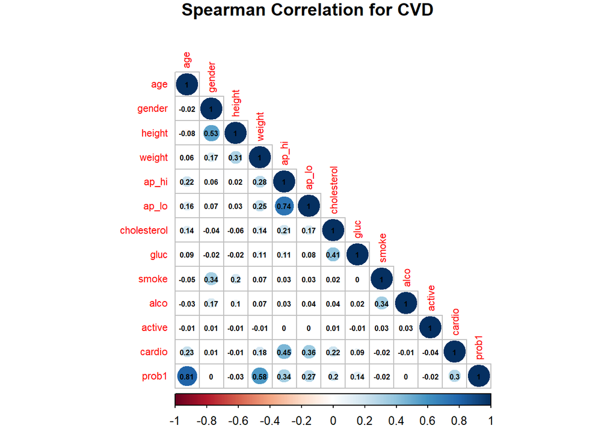

```r
# corrplot with spearman method for categorical variables
CVDcor <- cor(subset(CVDNum, select=-c(id, prob)), method="spearman")
#CVDcor
loadPkg("corrplot")
#corrplot.mixed(CVDcor, tl.pos = "lt", number.cex = .5, tl.cex=0.8)
corrplot(CVDcor, type="lower", addCoef.col="black", number.cex=0.5, tl.cex=0.7,title="Spearman Correlation for CVD", mar=c(0,0,1,0))
```

## 5.2 Will Age influence the CVD rate with other variables?

This is how we plot to see the influence of age.

```r
a1 <- ggplot(CVD_factor,aes(x = smoke , y = age , fill = cardio)) +
  geom_violin(alpha = 0.5, aes(linetype=NA)) +
  xlab("Smoke") + ylab("Age")


a2 <- ggplot(CVD_factor,aes(x = alco , y = age , fill = cardio)) +
  geom_violin(alpha = 0.5, aes(linetype=NA)) +
  xlab("Alco") + ylab("Age")


a3 <- ggplot(CVD_factor, aes(x=height, y=age, color= cardio)) +
  geom_point(size=.5,alpha=0.4)
```

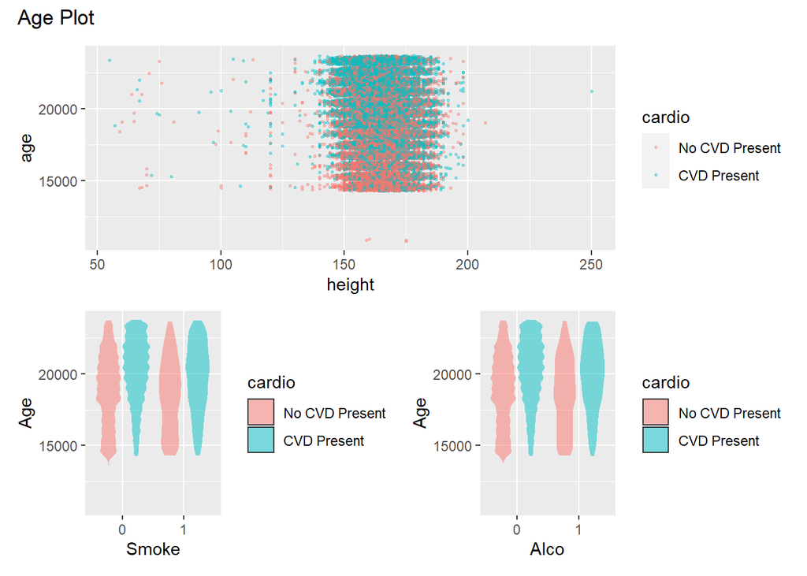

```r
a3/ (a1+a2) + plot_annotation(title = 'Age Plot')
```

First, Age and height show no correlation.

## 5.3 Will Height influence the CVD rate with other variables?

This is how we plot to see the influence of height.

```r
h1 <- ggplot(CVD_factor,aes(x = active , y = height , fill = cardio)) +
  geom_violin(alpha = 0.5, aes(linetype=NA)) +
  xlab("Active") + ylab("Height")



h2 <- ggplot(CVD_factor, aes(x=weight, y=height, color= cardio)) +
  geom_point(size=0.5,alpha=0.4)
```

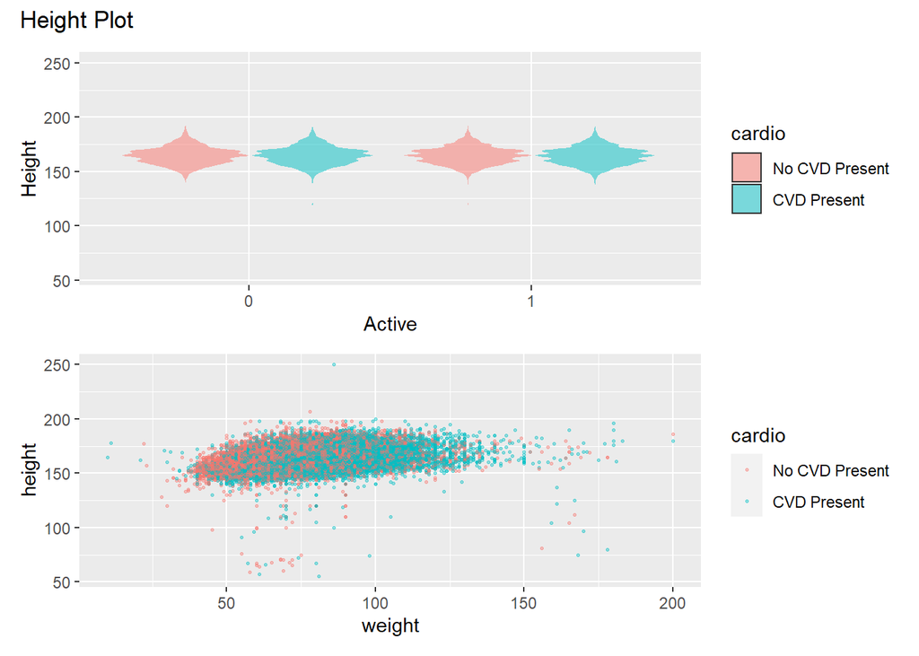

```r
h1/ h2 + plot_annotation(title = 'Height Plot')
```

Second, weight and height show a little positive correlation .

## 5.4 Will Weight influence the CVD rate with other variables?

This is how we plot to see the influence of weight.

```r
w1 <- ggplot(CVD_factor,aes(x = active , y = weight , fill = cardio)) +
  geom_violin(alpha = 0.5, aes(linetype=NA)) +
  xlab("Active") + ylab("Weight")


w2 <- ggplot(CVD_factor,aes(x = alco , y = weight , fill = cardio)) +
  geom_violin(alpha = 0.5, aes(linetype=NA)) +
  xlab("Alco") + ylab("Weight")
```

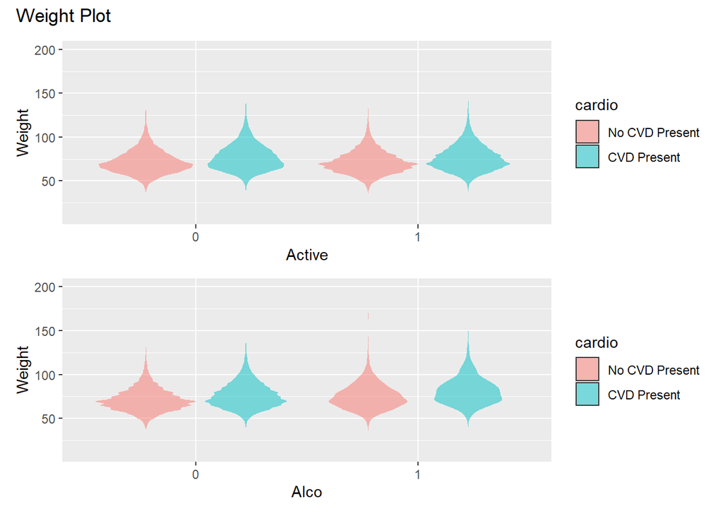

```r
w1/ w2 + plot_annotation(title = 'Weight Plot')
```

Second, for Alco, the sample groups of no alco (“0”) have little higher CVD rates.

# Models Comparison: Logistic Regression

This is how we convert to factor.

```r
df <- CVD
df$id <- NULL
df$gender <- factor(CVD$gender)
df$smoke <- factor(CVD$smoke)
df$alco <- factor(CVD$alco)
df$active <- factor(CVD$active)
df$cardio <- factor(CVD$cardio)
df$cholesterol <- factor(CVD$cholesterol)
df$gluc <- factor(CVD$gluc)
df$weight <- as.integer(CVD$weight)

levels(df$cardio) <- c("No", "Yes")
levels(df$gender) <- c("Female", "Male")
levels(df$cholesterol) <- c("Normal", "Above Normal", "Well Above Normal")
levels(df$gluc) <- c("Normal", "Above Normal", "Well Above Normal")
levels(df$smoke) <- c("No", "Yes")
levels(df$alco) <- c("No", "Yes")
levels(df$active) <- c("No", "Yes")
df <- na.omit(df)

str(df)
```

This is how we do the logistic regression.

```r
logistic_all <- glm(cardio ~ age + gender + height + weight + ap_hi + ap_lo + cholesterol + gluc + smoke + alco + active, data = df, family = "binomial")
summary(logistic_all)
```

```
##
## Call:
## glm(formula = cardio ~ age + gender + height + weight + ap_hi +
##     ap_lo + cholesterol + gluc + smoke + alco + active, family = "binomial",
##     data = df)
##
## Deviance Residuals:
##    Min      1Q  Median      3Q     Max
## -8.490  -0.963  -0.098   0.991   4.662
##
## Coefficients:
##                               Estimate Std. Error z value Pr(>|z|)
## (Intercept)                  -8.08e+00   2.21e-01  -36.53  < 2e-16 ***
## age                           1.48e-04   3.56e-06   41.73  < 2e-16 ***
## genderMale                    1.43e-02   2.11e-02    0.68     0.50
## height                       -5.63e-03   1.23e-03   -4.57  4.9e-06 ***
## weight                        1.52e-02   6.61e-04   23.02  < 2e-16 ***
## ap_hi                         3.95e-02   6.06e-04   65.24  < 2e-16 ***
## ap_lo                         3.00e-04   6.73e-05    4.46  8.2e-06 ***
## cholesterolAbove Normal       4.22e-01   2.59e-02   16.29  < 2e-16 ***
## cholesterolWell Above Normal  1.13e+00   3.44e-02   32.93  < 2e-16 ***
## glucAbove Normal              3.01e-02   3.44e-02    0.88     0.38
## glucWell Above Normal        -3.39e-01   3.81e-02   -8.89  < 2e-16 ***
## smokeYes                     -1.31e-01   3.32e-02   -3.96  7.6e-05 ***
## alcoYes                      -1.70e-01   4.03e-02   -4.21  2.6e-05 ***
## activeYes                    -2.10e-01   2.10e-02   -9.98  < 2e-16 ***
## ---
## Signif. codes:  0 '***' 0.001 '**' 0.01 '*' 0.05 '.' 0.1 ' ' 1
##
## (Dispersion parameter for binomial family taken to be 1)
##
##     Null deviance: 97041  on 69999  degrees of freedom
## Residual deviance: 80883  on 69986  degrees of freedom
## AIC: 80911
##
## Number of Fisher Scoring iterations: 25
```

This is how we do the logistic regression.

```r
logistic_1 <- glm(cardio ~ age + height + weight + ap_hi + ap_lo + cholesterol + gluc + smoke + alco + active, data = df, family = "binomial")
summary(logistic_1)
```

This is how we do the logistic regression.

```r
logistic_2 <- glm(cardio ~ age + height + weight + ap_hi + ap_lo + cholesterol + smoke + alco + active, data = df, family = "binomial")
summary(logistic_2)
```

```
##
## Call:
## glm(formula = cardio ~ age + height + weight + ap_hi + ap_lo +
##     cholesterol + smoke + alco + active, family = "binomial",
##     data = df)
##
## Deviance Residuals:
##    Min      1Q  Median      3Q     Max
## -8.490  -0.964  -0.099   0.990   4.668
##
## Coefficients:
##                               Estimate Std. Error z value Pr(>|z|)
## (Intercept)                  -8.12e+00   2.03e-01  -40.06  < 2e-16 ***
## age                           1.48e-04   3.55e-06   41.55  < 2e-16 ***
## height                       -5.36e-03   1.10e-03   -4.86  1.2e-06 ***
## weight                        1.52e-02   6.59e-04   23.02  < 2e-16 ***
## ap_hi                         3.96e-02   6.05e-04   65.49  < 2e-16 ***
## ap_lo                         3.03e-04   6.77e-05    4.48  7.6e-06 ***
## cholesterolAbove Normal       4.23e-01   2.50e-02   16.96  < 2e-16 ***
## cholesterolWell Above Normal  9.86e-01   2.96e-02   33.27  < 2e-16 ***
## smokeYes                     -1.22e-01   3.20e-02   -3.81  0.00014 ***
## alcoYes                      -1.64e-01   4.01e-02   -4.09  4.3e-05 ***
## activeYes                    -2.08e-01   2.10e-02   -9.91  < 2e-16 ***
## ---
## Signif. codes:  0 '***' 0.001 '**' 0.01 '*' 0.05 '.' 0.1 ' ' 1
##
## (Dispersion parameter for binomial family taken to be 1)
##
##     Null deviance: 97041  on 69999  degrees of freedom
## Residual deviance: 80984  on 69989  degrees of freedom
## AIC: 81006
##
## Number of Fisher Scoring iterations: 9
```

This is how we compute the coefficient.

```r
expcoef = exp(coef(logistic_2))
summary(expcoef)
xkabledply( as.table(expcoef), title = "Exponential of coefficients in Cardio")
```

This is how we create the confusion matrix.

```r
loadPkg("regclass")
confusion_matrix(logistic_2)
```

```
##            Predicted No Predicted Yes Total
## Actual No         26856          8165 35021
## Actual Yes        11312         23667 34979
## Total             38168         31832 70000
```

```r
cfmatrix1 = confusion_matrix(logistic_2)
accuracy1 <- (cfmatrix1[1,1]+cfmatrix1[2,2])/cfmatrix1[3,3]
precision1 <- cfmatrix1[2,2]/(cfmatrix1[2,2]+cfmatrix1[1,2])
recall1 <- cfmatrix1[2,2]/(cfmatrix1[2,2]+cfmatrix1[2,1])
specificity1 <- cfmatrix1[1,1]/(cfmatrix1[1,1]+cfmatrix1[1,2])
F1_score1 <- 2*(precision1)*(recall1)/(precision1 + recall1)
accuracy1
```

```
## [1] 0.722
```

```r
precision1
```

```
## [1] 0.743
```

```r
recall1
```

```
## [1] 0.677
```

```r
specificity1
```

```
## [1] 0.767
```

```r
F1_score1
```

```
## [1] 0.708
```

```r
xkabledply( confusion_matrix(logistic_2), title = "Confusion matrix from Logit Model" )
```

This is how we plot the ROC curve.

```r
loadPkg("pROC")
prob <- predict(logistic_2, type = "response")
df$prob <- prob
h <- roc(cardio ~ prob, data = df)
auc(h)
```

```
## Area under the curve: 0.785
```

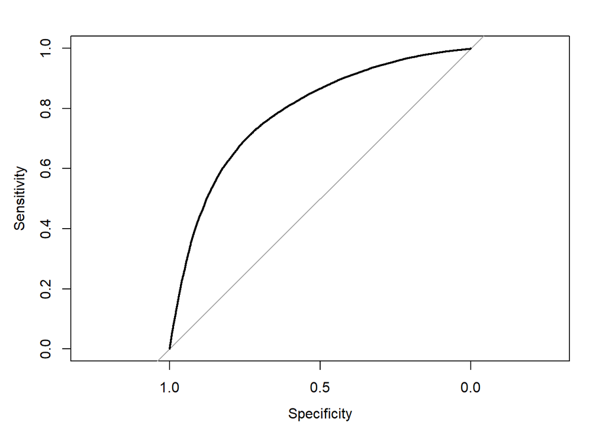

```r
plot(h)
```

Not a good fit.

# Feature Selection

This is how we plot the adjusted R square.

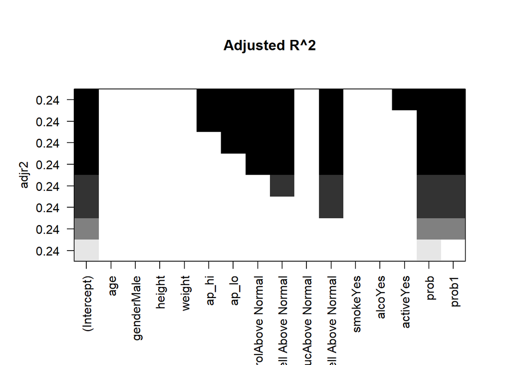

```r
loadPkg("leaps")
reg.leaps <- regsubsets(cardio ~ ., data = df, nbest = 1, method = "exhaustive")
plot(reg.leaps, scale = "adjr2", main = "Adjusted R^2")
```

This is how we plot the BIC.

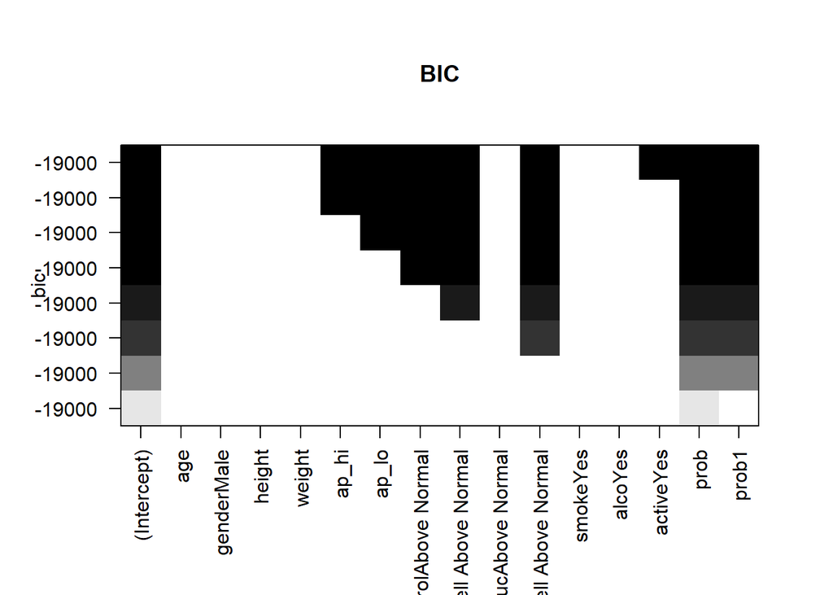

```r
plot(reg.leaps, scale = "bic", main = "BIC")
```

This is how we plot the Cp.

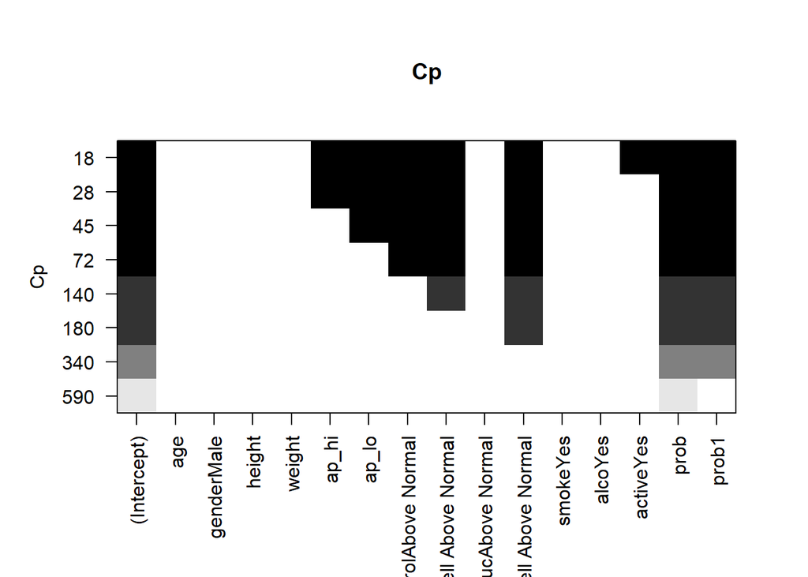

```r
plot(reg.leaps, scale = "Cp", main = "Cp")
```

Close results.

# Models Comparison: KNN

This is how we convert to factor.

```r
df <- CVD
df$id <- NULL
df$gender <- factor(CVD$gender)
df$smoke <- factor(CVD$smoke)
df$alco <- factor(CVD$alco)
df$active <- factor(CVD$active)
df$cardio <- factor(CVD$cardio)
df$cholesterol <- factor(CVD$cholesterol)
df$gluc <- factor(CVD$gluc)
df$weight <- as.integer(CVD$weight)

levels(df$cardio) <- c("No", "Yes")
levels(df$gender) <- c("Female", "Male")
levels(df$cholesterol) <- c("Normal", "Above Normal", "Well Above Normal")
levels(df$gluc) <- c("Normal", "Above Normal", "Well Above Normal")
levels(df$smoke) <- c("No", "Yes")
levels(df$alco) <- c("No", "Yes")
levels(df$active) <- c("No", "Yes")
df <- na.omit(df)

str(df)
```

```r
df_num <- df
for(i in 1:12){
  if (!(i %in% c(1,3:6))){
    df_num[,i] = as.numeric(df_num[,i])
  }
}
str(df_num)
```

This is how we convert variables to numeric.

```r
#convert variables to numeric
scale1 <- subset(df_num, select = -cardio)
scale1$cardio <- df$cardio
str(scale1)
scale1[c(1,3,4,5,6)] <- as.data.frame(scale(scale1[c(1,3,4,5,6)], center = TRUE, scale = TRUE))
set.seed(1)
df_sample <- sample(2, nrow(scale1), replace = TRUE, prob = c(0.75,0.25))
df_train <- scale1[df_sample==1, 1:11]
df_test <- scale1[df_sample==2, 1:11]
df.trainLabels <- df[df_sample==1, 12]
df.testLabels <- df[df_sample==2, 12]
str(df_train)
str(df_test)
```

This is how we choose K.

This is how we plot the KNN.

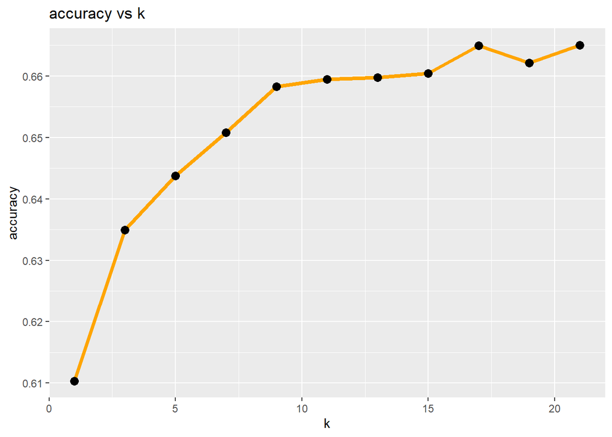

```r
knn_different_k = sapply(seq(1, 21, by = 2),
                         function(x) chooseK(x,
                                             train_set = df_train,
                                             val_set = df_test,
                                             train_class = df.trainLabels,
                                             val_class = df.testLabels))
knn_different_k = data.frame(k = knn_different_k[1,],
                             accuracy = knn_different_k[2,])
library("ggplot2")
ggplot(knn_different_k,
       aes(x = k, y = accuracy)) +
  geom_line(color = "orange", size = 1.5) +
  geom_point(size = 3) +
  labs(title = "accuracy vs k")
```

```r
xkabledply((knn_different_k))
```

Model: k ~ accuracy

| k | accuracy |
| --- | --- |
| 1 | 0.610 |
| 3 | 0.635 |
| 5 | 0.644 |
| 7 | 0.651 |
| 9 | 0.658 |
| 11 | 0.659 |
| 13 | 0.660 |
| 15 | 0.660 |
| 17 | 0.665 |
| 19 | 0.662 |
| 21 | 0.665 |

`k=17` is a decent choice.

```r
pred <- knn(train = df_train, test = df_test, cl=df.trainLabels, k=17)
pred
```

[output not shown]

[output cut: 963 more lines]

```r
loadPkg("gmodels")
churnPredCross <- CrossTable(df.testLabels, pred, prop.chisq = FALSE)
```

```
##
##
##    Cell Contents
## |-------------------------|
## |                       N |
## |           N / Row Total |
## |           N / Col Total |
## |         N / Table Total |
## |-------------------------|
##
##
## Total Observations in Table:  17570
##
##
##               | pred
## df.testLabels |        No |       Yes | Row Total |
## --------------|-----------|-----------|-----------|
##            No |      6040 |      2641 |      8681 |
##               |     0.696 |     0.304 |     0.494 |
##               |     0.651 |     0.319 |           |
##               |     0.344 |     0.150 |           |
## --------------|-----------|-----------|-----------|
##           Yes |      3245 |      5644 |      8889 |
##               |     0.365 |     0.635 |     0.506 |
##               |     0.349 |     0.681 |           |
##               |     0.185 |     0.321 |           |
## --------------|-----------|-----------|-----------|
##  Column Total |      9285 |      8285 |     17570 |
##               |     0.528 |     0.472 |           |
## --------------|-----------|-----------|-----------|
##
##
```

accuracy = 0.6648  
precision = 0.6809  
recall = 0.6348  
specificity = 0.6954  
F1_score = 0.657